# The Relationship between Low-Income Childcare Funding and Educational Outcomes at a Neighborhood Level

STA304 Student Who May Like Pineapple Pizza

2020-09-28T01:10:00-5:00

# Abstract

In this report, we investigate whether subsidizing low-income childcare for age 0-5 children can meaningfully improve long-term educational outcomes (as measured by grade 9 graduation rates) as measured at a neighborhood-level.

# Introduction

A question involving assistive funding for early-aged children is whether subsidized child-care can improve long-term educational outcomes. If such a relationship can be found, then educational decision makers may wish to further fund early childcare. If such a relationship doesn’t exist, then funding which is purely for educational purposes may be better directed towards other facilities and services.

On a neighborhood-level, we investigate whether there is a is a statistically significant relationship between (1) access to early (age 0-5) child care in low-income households and (2) educational outcomes as measured by grade 9 graduation rate as of the year 2008 in Catholic schools. Based on a regression and hypothesis across this data, we discovered that there is not sufficient evidence across these a statistically significant relationship between the two factors at a neighborhood level.

While we find reasonably conclusive results at a neighborhood-level for this report, it is worth noting that the population of children who qualify for assistive childcare may be substantially smaller than the total graduating population. Furthermore, while the most recent neighborhood-level dataset containing necessary information is from 2008, it may be beneficial to perform this analysis over two different datasets at different periods of time, where the graduation data for students is compared to children from a past year from when the students were within the age range to benefit from assistive care. As the data is from 2008, it is also possible that factors such as the Great Recession temporarily impacted educational outcomes. It may be worth further investigating whether such financial assistance can benefit a more granular cohort of students who do benefit from assistive care over a longitudial study.

# Data

This analysis is split into three parts: a review of the Toronto Wellness Education Dataset, a review of the Toronto Wellness Economic Dataset, and an analysis of the relationship between the two.

## Toronto Education Dataset

Let us first inspect the Toronto Wellness Education dataset.

```r
package <- show_package("e6639dca-5caf-4ceb-87c5-2e75f1a09f8e")
edu_data <- package %>% list_package_resources() %>% get_resource()

# The dataset is split into three parts: the first part describes the columns,
# the second part contains data for 2008, and the third part contains data for
# 2011. However, only the 2008 dataset contains the information that we want.
edu_data <- as.data.frame(edu_data[2])
names(edu_data)
```

```
##  [1] "RawData_Ref2008.Neighbourhood"
##  [2] "RawData_Ref2008.Neighbourhood.Id"
##  [3] "RawData_Ref2008.Catholic.School.Graduation"
##  [4] "RawData_Ref2008.Catholic.School.Literacy"
##  [5] "RawData_Ref2008.Catholic.University.Applicants"
##  [6] "RawData_Ref2008.Early.Development.Instrument"
##  [7] "RawData_Ref2008.Library.Activity"
##  [8] "RawData_Ref2008.Library.Open.Hours"
##  [9] "RawData_Ref2008.Library.Program.Attendance"
## [10] "RawData_Ref2008.Library.Programs"
## [11] "RawData_Ref2008.Library.Space"
```

Column 2 serves as an identifier for the neighborhood out of 140 neighborhoods in Toronto. Of particular interest is column 3: “RawData_Ref2008.Catholic.School.Graduation” which describes the portion of students in Catholic schools in a grade 9 cohort who graduated at the end of 5 years within the census tract, out of all students in the cohort living in the census tract.

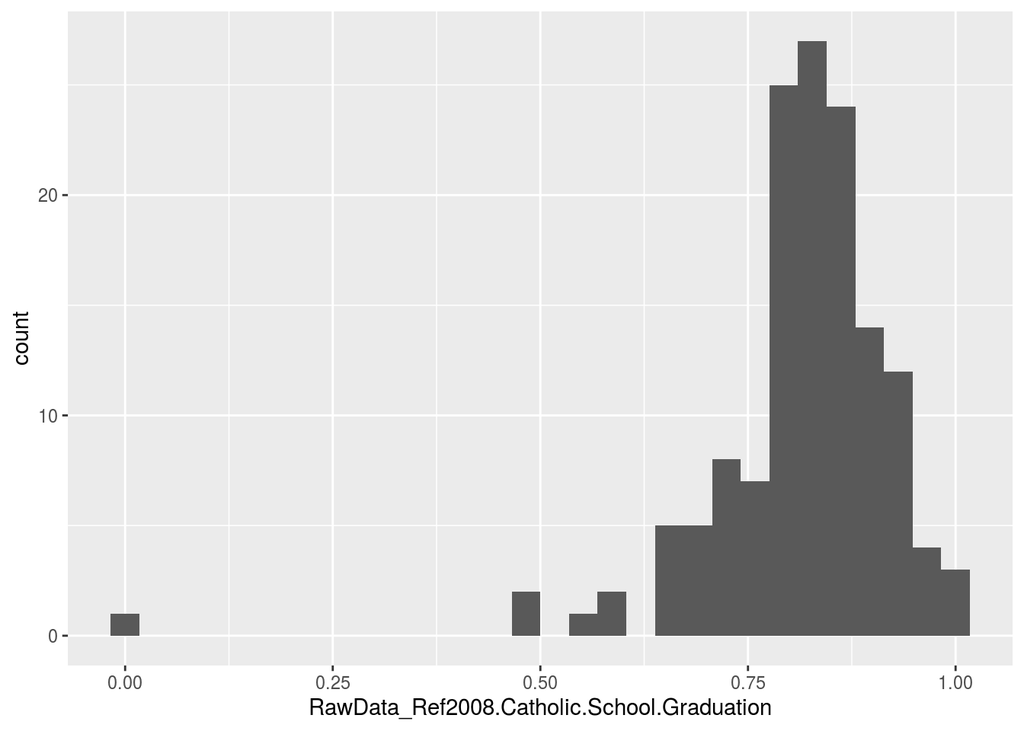

```r
edu_data %>%
  ggplot(aes(x = RawData_Ref2008.Catholic.School.Graduation)) +
    geom_histogram()
```

Generally we see that nearly all districts boast a graduation rate of over 60%, with a majority of districts keeping a graduation rate of above 75%. There is one particular outlier sample which appears to have a graduation rate of 0, however. This neighborhood is the Forest Hill South neighborhood (#101). This specific labelling may be incorrect, given that - based on the same dataset - 50% of students within the Neighborhood passed the Ontario Secondary School Literary Test and 60% of the Neighborhood’s students applied to a University.

This is the singular major outlier within a histogram that otherwise appears to be reasonably-distributed, so we proceed to prune this one particular sample from the dataset.

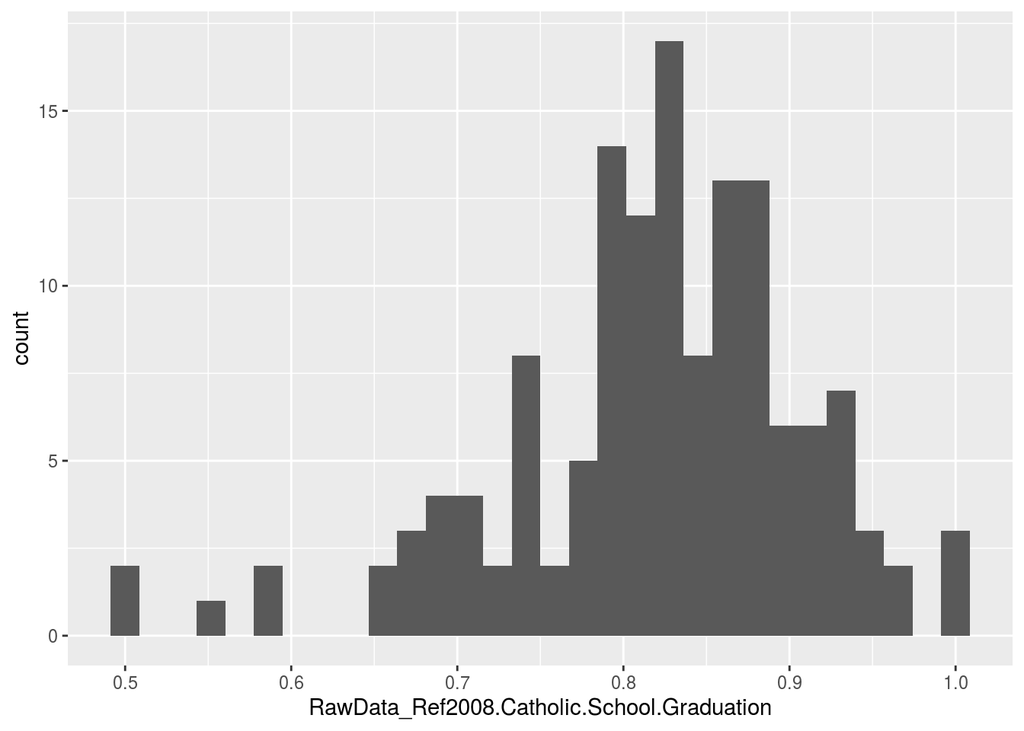

```r
edu_data = edu_data[-c(101),]
edu_data %>%
  ggplot(aes(x = RawData_Ref2008.Catholic.School.Graduation)) +
    geom_histogram()
```

The exclusion of the outlier sample results in a much cleaner histogram.

## Toronto Economic Dataset

```r
package2 <- show_package("6a62d263-632e-489b-bd3d-2adc5056beca")
econ_data <- package2 %>% list_package_resources() %>% get_resource()
```

```r
# The dataset is split into three parts similar to the education data. We use
# the 2008 dataset to match the previous one.
econ_data <- as.data.frame(econ_data[2])
names(econ_data)
```

```
## [1] "RawData.Ref.Period.2008....1"      "RawData.Ref.Period.2008....2"
## [3] "RawData.Ref.Period.2008.Economics" "RawData.Ref.Period.2008....4"
## [5] "RawData.Ref.Period.2008....5"      "RawData.Ref.Period.2008....6"
## [7] "RawData.Ref.Period.2008....7"      "RawData.Ref.Period.2008....8"
## [9] "RawData.Ref.Period.2008....9"
```

The header appears to have been misloaded. We proceed to debug the issue.

```r
econ_data[1,]
```

```
##   RawData.Ref.Period.2008....1 RawData.Ref.Period.2008....2
## 1                Neighbourhood             Neighbourhood Id
##   RawData.Ref.Period.2008.Economics RawData.Ref.Period.2008....4
## 1              Access to Child Care           Business Licensing
##   RawData.Ref.Period.2008....5 RawData.Ref.Period.2008....6
## 1                   Businesses            Child Care Spaces
##   RawData.Ref.Period.2008....7 RawData.Ref.Period.2008....8
## 1     Inequality (Gini coeff.)             Local Employment
##   RawData.Ref.Period.2008....9
## 1 Social Assistance Recipients
```

As we can see, this dataset is not well-formed, because there is an additional row with just the term ‘Economics’ that is above the actual header. This results in R loading ‘Economics’ as the sole header term and the actual header being loaded into the first term. Luckily, we can easily work around this issue for our analysis and later goal, so we temporarily ignore this.

The column that is of interest to us is row 3 (misnamed “RawData.Ref.Period.2008.Economics” due to the header issue, but we’ll work with it) which describes the portion of children aged 0 - 5, who belong to households below LICO (Low-Income Cut-Offs as defined by the Canadian government), that are receiving a child care subsidy.

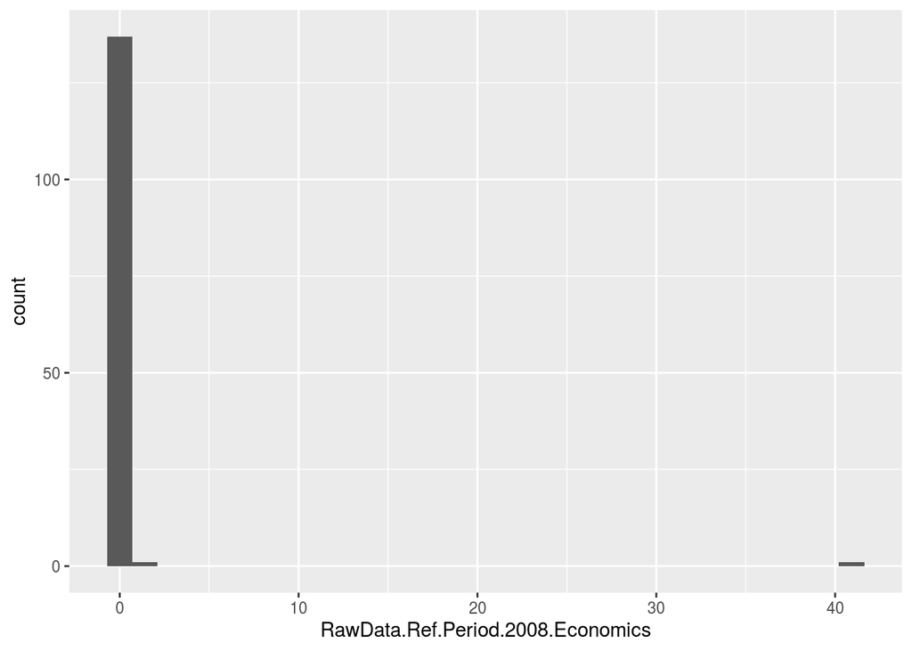

```r
# Eliminate the unloaded real header row as we already know that we'll use column 3
econ_data = econ_data[-1,]

# Eliminate the 101-th neighborhood as done previously for the outlier in the education dataset
econ_data = econ_data[-c(101),]

# Convert 3rd row to numeric from chartype (due to header misloading)
econ_data$RawData.Ref.Period.2008.Economics <- as.numeric(as.character(econ_data$RawData.Ref.Period.2008.Economics))

econ_data %>%
  ggplot(aes(x = RawData.Ref.Period.2008.Economics)) +
    geom_histogram()
```

However, it is worth noting that the 140th neighborhood (Guildwood) and 79th neighborhood (University) also appear to have their data misentered - the remaining data is on a scale from 0 to 1, but this entry appears to be from 0 to 100, so these outlier samples are pruned for convenience as they would constitute major outliers.

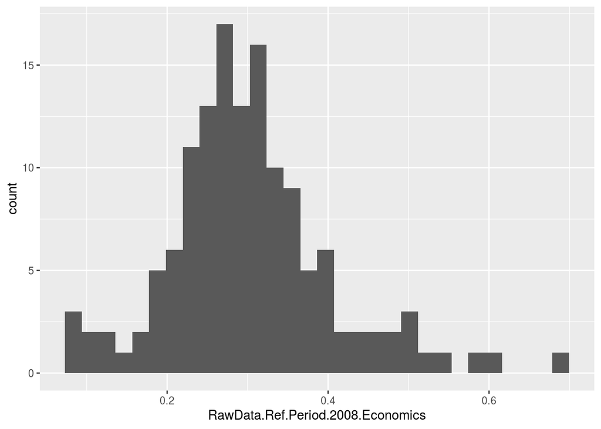

```r
econ_data = econ_data[-c(79, 139),]
edu_data = edu_data[-c(79, 139),]

econ_data %>%
  ggplot(aes(x = RawData.Ref.Period.2008.Economics)) +
    geom_histogram()
```

Once again, we arrive at a significantly cleaner histogram after pruning.